# 2_4_excercise

### Conceptual

#### Q1

$a)$ Overall performance of flexible methods will be better.

> From equation 2.7, performance depends on minimizing $Variance$ (dependent on data set) and $Bias$ (dependent on flexibility)
- Large sample size $n$ on $Variance$:
  - Inflexible models naturally has lower variance due to assumptions on the model
  - Flexible models have higher variance due to the degree of freedom it has; however, since $n$ is large, the effect is negligible \

  $\rarr$ Both types have roughly equal $Variance$
- Small number of predictor $p$ on $Bias$:
  - Inflexible models tends to have higher bias due to assumptions on the model
  - Flexible models have lower bias (unless the true model is strictly linear in the first place). Additionally, small number of predictor $p$ also helps to reduce the complexity of the model, meaning that it's less likely to overfit the model

  $\rarr$ Flexible models have lower $Bias$ \

$b)$ Opposite effect of part ($a$) $\rarr$ Inflexible methods will perform better

$c)$ Assume small sample size, $Variance$ is large for both types. True model is highly non-linear $\rarr$ inflexible methods have higher $Bias$ $\rarr$ flexible methods perform better

$d)$ Var($\epsilon$) is the optimal model. As it is extremely high, regardless of model type, performance will not be good. But flexible methods also suffer from overfitting to the noise of the data, leading to higher $Variance$, this is avoided by inflexible methods. $Bias$ of inflexible methods are higher. However, since the true model is weak, it is likely that there is not real relationship between predictors and response, so the effect of $Bias$ is less.  
Inflexible methods perform better

#### Q2

$a)$ regression, inference, $n$ = 500, $p$ = 4

$b)$ classification, prediction, $n$ = 20, $p$ = 14

$c)$ regression, prediction, $n$ = 52, $p$ = 4

#### Q3

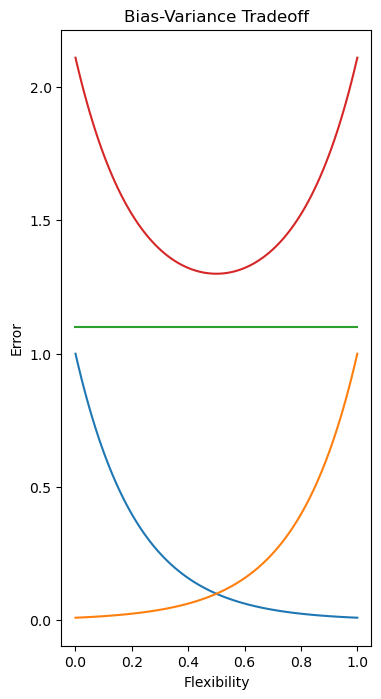

```python
from matplotlib.pyplot import subplots
import numpy as np
fig, ax = subplots(figsize=(4, 8))
x = np.linspace(0, 1, 100)
# Bias
y_bias = 0.01**x
# Variance
y_var = 0.01**(1-x)
# Irreducible error
y_irreducible = np.ones_like(x) + 0.1   # add 0.1 for visual separation between lines
# Total loss
y_total = y_bias + y_var + y_irreducible

ax.set_xlabel('Flexibility')
ax.set_ylabel('Error')
ax.set_title('Bias-Variance Tradeoff')
y_types = [y_bias, y_var, y_irreducible, y_total]
for y_type in y_types:
    ax.plot(x, y_type)
```

#### Q4

#### Q5

- Advantages:
  - Lower bias
  - More adaptable to complex model with non-linear relationship
- Disadvanges:
  - Larger variance
  - Requires large amount of sample size, making it prone to overfitting
- Preferable cases:
  - Problem with complex relationship
  - Prediction is more important than inference
- Less preferable cases:
  - Problem with simple relationship
  - Inference is more important than prediction

#### Q6

- $Parametric$ approaches:
  - Assume relationship between predictors and response (e.g. linear regression assumes linear relationship)
  - Train model by finding the coefficient for the assumed relationship (usually small)
- $Non-parametric$ approaches:
  - No assumption on the relationship
  - Train model by finding large number of parameters
- Advantages for parametric approaches:
  - Simpler model with high interpretability
  - Less dependent on data (low variance) $\rarr$ less prone to overfitting
- Disadvantages:
  - Inflexible problems with complex relationships
  - Make assumptions on the model $\rarr$ high bias

#### Q7

$a)$

```python
import pandas as pd
df = pd.DataFrame({'Obs': [1, 2, 3, 4, 5, 6],
                   'X1': [0, 2, 0, 0, -1, 1],
                   'X2': [3, 0, 1, 1, 0, -1],
                   'X3': [0, 0, 3, 2, 1, 1],
                   'Y': ['Red', 'Red', 'Red', 'Green', 'Green', 'Red']})

df
```

|  | Obs | X1 | X2 | X3 | Y |
| --- | --- | --- | --- | --- | --- |
| 0 | 1 | 0 | 3 | 0 | Red |
| 1 | 2 | 2 | 0 | 0 | Red |
| 2 | 3 | 0 | 1 | 3 | Red |
| 3 | 4 | 0 | 1 | 2 | Green |
| 4 | 5 | -1 | 0 | 1 | Green |
| 5 | 6 | 1 | -1 | 1 | Red |

```python
test_point = np.array([0, 0, 0])

def find_euclidean_dist( df, x ):
    return np.sqrt(np.sum((df[['X1', 'X2', 'X3']] - x)**2, axis=1))

df['Euclid_dist'] = find_euclidean_dist( df, test_point )
df
```

|  | Obs | X1 | X2 | X3 | Y | Euclid_dist |
| --- | --- | --- | --- | --- | --- | --- |
| 0 | 1 | 0 | 3 | 0 | Red | 3.000000 |
| 1 | 2 | 2 | 0 | 0 | Red | 2.000000 |
| 2 | 3 | 0 | 1 | 3 | Red | 3.162278 |
| 3 | 4 | 0 | 1 | 2 | Green | 2.236068 |
| 4 | 5 | -1 | 0 | 1 | Green | 1.414214 |
| 5 | 6 | 1 | -1 | 1 | Red | 1.732051 |

$b)$

```python
def k_nearest(k):
    """Find most common `Y` from `df` from `k` nearest neighbors by Euclidean distance"""
    return df.nsmallest(k, columns='Euclid_dist')['Y'].mode()

k_nearest(1)
```

```
0    Green
Name: Y, dtype: object
```

$c)$

```python
k_nearest(3)
```

```
0    Red
Name: Y, dtype: object
```

$d)$ Since the decision boundary is highly non-linear, more flexible methods would adapt better to the nonlinearity. Smaller `k` allows model to be more flexible.

### Applied

#### Q8

$a)$

```python
college = pd.read_csv('College.csv')
```

$b)$

```python
college
```

|  | Unnamed: 0 | Private | Apps | Accept | Enroll | Top10perc | Top25perc | F.Undergrad | P.Undergrad | Outstate | Room.Board | Books | Personal | PhD | Terminal | S.F.Ratio | perc.alumni | Expend | Grad.Rate |
| --- | --- | --- | --- | --- | --- | --- | --- | --- | --- | --- | --- | --- | --- | --- | --- | --- | --- | --- | --- |
| 0 | Abilene Christian University | Yes | 1660 | 1232 | 721 | 23 | 52 | 2885 | 537 | 7440 | 3300 | 450 | 2200 | 70 | 78 | 18.1 | 12 | 7041 | 60 |
| 1 | Adelphi University | Yes | 2186 | 1924 | 512 | 16 | 29 | 2683 | 1227 | 12280 | 6450 | 750 | 1500 | 29 | 30 | 12.2 | 16 | 10527 | 56 |
| 2 | Adrian College | Yes | 1428 | 1097 | 336 | 22 | 50 | 1036 | 99 | 11250 | 3750 | 400 | 1165 | 53 | 66 | 12.9 | 30 | 8735 | 54 |
| 3 | Agnes Scott College | Yes | 417 | 349 | 137 | 60 | 89 | 510 | 63 | 12960 | 5450 | 450 | 875 | 92 | 97 | 7.7 | 37 | 19016 | 59 |
| 4 | Alaska Pacific University | Yes | 193 | 146 | 55 | 16 | 44 | 249 | 869 | 7560 | 4120 | 800 | 1500 | 76 | 72 | 11.9 | 2 | 10922 | 15 |
| ... | ... | ... | ... | ... | ... | ... | ... | ... | ... | ... | ... | ... | ... | ... | ... | ... | ... | ... | ... |
| 772 | Worcester State College | No | 2197 | 1515 | 543 | 4 | 26 | 3089 | 2029 | 6797 | 3900 | 500 | 1200 | 60 | 60 | 21.0 | 14 | 4469 | 40 |
| 773 | Xavier University | Yes | 1959 | 1805 | 695 | 24 | 47 | 2849 | 1107 | 11520 | 4960 | 600 | 1250 | 73 | 75 | 13.3 | 31 | 9189 | 83 |
| 774 | Xavier University of Louisiana | Yes | 2097 | 1915 | 695 | 34 | 61 | 2793 | 166 | 6900 | 4200 | 617 | 781 | 67 | 75 | 14.4 | 20 | 8323 | 49 |
| 775 | Yale University | Yes | 10705 | 2453 | 1317 | 95 | 99 | 5217 | 83 | 19840 | 6510 | 630 | 2115 | 96 | 96 | 5.8 | 49 | 40386 | 99 |
| 776 | York College of Pennsylvania | Yes | 2989 | 1855 | 691 | 28 | 63 | 2988 | 1726 | 4990 | 3560 | 500 | 1250 | 75 | 75 | 18.1 | 28 | 4509 | 99 |

777 rows × 19 columns

```python
college2 = pd.read_csv('College.csv', index_col=0)  # use unnamed column 0 as index
college2
```

|  | Private | Apps | Accept | Enroll | Top10perc | Top25perc | F.Undergrad | P.Undergrad | Outstate | Room.Board | Books | Personal | PhD | Terminal | S.F.Ratio | perc.alumni | Expend | Grad.Rate |
| --- | --- | --- | --- | --- | --- | --- | --- | --- | --- | --- | --- | --- | --- | --- | --- | --- | --- | --- |
| Abilene Christian University | Yes | 1660 | 1232 | 721 | 23 | 52 | 2885 | 537 | 7440 | 3300 | 450 | 2200 | 70 | 78 | 18.1 | 12 | 7041 | 60 |
| Adelphi University | Yes | 2186 | 1924 | 512 | 16 | 29 | 2683 | 1227 | 12280 | 6450 | 750 | 1500 | 29 | 30 | 12.2 | 16 | 10527 | 56 |
| Adrian College | Yes | 1428 | 1097 | 336 | 22 | 50 | 1036 | 99 | 11250 | 3750 | 400 | 1165 | 53 | 66 | 12.9 | 30 | 8735 | 54 |
| Agnes Scott College | Yes | 417 | 349 | 137 | 60 | 89 | 510 | 63 | 12960 | 5450 | 450 | 875 | 92 | 97 | 7.7 | 37 | 19016 | 59 |
| Alaska Pacific University | Yes | 193 | 146 | 55 | 16 | 44 | 249 | 869 | 7560 | 4120 | 800 | 1500 | 76 | 72 | 11.9 | 2 | 10922 | 15 |
| ... | ... | ... | ... | ... | ... | ... | ... | ... | ... | ... | ... | ... | ... | ... | ... | ... | ... | ... |
| Worcester State College | No | 2197 | 1515 | 543 | 4 | 26 | 3089 | 2029 | 6797 | 3900 | 500 | 1200 | 60 | 60 | 21.0 | 14 | 4469 | 40 |
| Xavier University | Yes | 1959 | 1805 | 695 | 24 | 47 | 2849 | 1107 | 11520 | 4960 | 600 | 1250 | 73 | 75 | 13.3 | 31 | 9189 | 83 |
| Xavier University of Louisiana | Yes | 2097 | 1915 | 695 | 34 | 61 | 2793 | 166 | 6900 | 4200 | 617 | 781 | 67 | 75 | 14.4 | 20 | 8323 | 49 |
| Yale University | Yes | 10705 | 2453 | 1317 | 95 | 99 | 5217 | 83 | 19840 | 6510 | 630 | 2115 | 96 | 96 | 5.8 | 49 | 40386 | 99 |
| York College of Pennsylvania | Yes | 2989 | 1855 | 691 | 28 | 63 | 2988 | 1726 | 4990 | 3560 | 500 | 1250 | 75 | 75 | 18.1 | 28 | 4509 | 99 |

777 rows × 18 columns

```python
college2 = pd.read_csv('College.csv', index_col=0)
college3 = college.rename({'Unnamed: 0': 'College'}, axis=1)
college3 = college3.set_index('College')
college3
```

| College | Private | Apps | Accept | Enroll | Top10perc | Top25perc | F.Undergrad | P.Undergrad | Outstate | Room.Board | Books | Personal | PhD | Terminal | S.F.Ratio | perc.alumni | Expend | Grad.Rate |
| --- | --- | --- | --- | --- | --- | --- | --- | --- | --- | --- | --- | --- | --- | --- | --- | --- | --- | --- |
| Abilene Christian University | Yes | 1660 | 1232 | 721 | 23 | 52 | 2885 | 537 | 7440 | 3300 | 450 | 2200 | 70 | 78 | 18.1 | 12 | 7041 | 60 |
| Adelphi University | Yes | 2186 | 1924 | 512 | 16 | 29 | 2683 | 1227 | 12280 | 6450 | 750 | 1500 | 29 | 30 | 12.2 | 16 | 10527 | 56 |
| Adrian College | Yes | 1428 | 1097 | 336 | 22 | 50 | 1036 | 99 | 11250 | 3750 | 400 | 1165 | 53 | 66 | 12.9 | 30 | 8735 | 54 |
| Agnes Scott College | Yes | 417 | 349 | 137 | 60 | 89 | 510 | 63 | 12960 | 5450 | 450 | 875 | 92 | 97 | 7.7 | 37 | 19016 | 59 |
| Alaska Pacific University | Yes | 193 | 146 | 55 | 16 | 44 | 249 | 869 | 7560 | 4120 | 800 | 1500 | 76 | 72 | 11.9 | 2 | 10922 | 15 |
| ... | ... | ... | ... | ... | ... | ... | ... | ... | ... | ... | ... | ... | ... | ... | ... | ... | ... | ... |
| Worcester State College | No | 2197 | 1515 | 543 | 4 | 26 | 3089 | 2029 | 6797 | 3900 | 500 | 1200 | 60 | 60 | 21.0 | 14 | 4469 | 40 |
| Xavier University | Yes | 1959 | 1805 | 695 | 24 | 47 | 2849 | 1107 | 11520 | 4960 | 600 | 1250 | 73 | 75 | 13.3 | 31 | 9189 | 83 |
| Xavier University of Louisiana | Yes | 2097 | 1915 | 695 | 34 | 61 | 2793 | 166 | 6900 | 4200 | 617 | 781 | 67 | 75 | 14.4 | 20 | 8323 | 49 |
| Yale University | Yes | 10705 | 2453 | 1317 | 95 | 99 | 5217 | 83 | 19840 | 6510 | 630 | 2115 | 96 | 96 | 5.8 | 49 | 40386 | 99 |
| York College of Pennsylvania | Yes | 2989 | 1855 | 691 | 28 | 63 | 2988 | 1726 | 4990 | 3560 | 500 | 1250 | 75 | 75 | 18.1 | 28 | 4509 | 99 |

777 rows × 18 columns

```python
college = college3
```

$c)$

```python
college.describe()
```

|  | Apps | Accept | Enroll | Top10perc | Top25perc | F.Undergrad | P.Undergrad | Outstate | Room.Board | Books | Personal | PhD | Terminal | S.F.Ratio | perc.alumni | Expend | Grad.Rate |
| --- | --- | --- | --- | --- | --- | --- | --- | --- | --- | --- | --- | --- | --- | --- | --- | --- | --- |
| count | 777.000000 | 777.000000 | 777.000000 | 777.000000 | 777.000000 | 777.000000 | 777.000000 | 777.000000 | 777.000000 | 777.000000 | 777.000000 | 777.000000 | 777.000000 | 777.000000 | 777.000000 | 777.000000 | 777.00000 |
| mean | 3001.638353 | 2018.804376 | 779.972973 | 27.558559 | 55.796654 | 3699.907336 | 855.298584 | 10440.669241 | 4357.526384 | 549.380952 | 1340.642214 | 72.660232 | 79.702703 | 14.089704 | 22.743887 | 9660.171171 | 65.46332 |
| std | 3870.201484 | 2451.113971 | 929.176190 | 17.640364 | 19.804778 | 4850.420531 | 1522.431887 | 4023.016484 | 1096.696416 | 165.105360 | 677.071454 | 16.328155 | 14.722359 | 3.958349 | 12.391801 | 5221.768440 | 17.17771 |
| min | 81.000000 | 72.000000 | 35.000000 | 1.000000 | 9.000000 | 139.000000 | 1.000000 | 2340.000000 | 1780.000000 | 96.000000 | 250.000000 | 8.000000 | 24.000000 | 2.500000 | 0.000000 | 3186.000000 | 10.00000 |
| 25% | 776.000000 | 604.000000 | 242.000000 | 15.000000 | 41.000000 | 992.000000 | 95.000000 | 7320.000000 | 3597.000000 | 470.000000 | 850.000000 | 62.000000 | 71.000000 | 11.500000 | 13.000000 | 6751.000000 | 53.00000 |
| 50% | 1558.000000 | 1110.000000 | 434.000000 | 23.000000 | 54.000000 | 1707.000000 | 353.000000 | 9990.000000 | 4200.000000 | 500.000000 | 1200.000000 | 75.000000 | 82.000000 | 13.600000 | 21.000000 | 8377.000000 | 65.00000 |
| 75% | 3624.000000 | 2424.000000 | 902.000000 | 35.000000 | 69.000000 | 4005.000000 | 967.000000 | 12925.000000 | 5050.000000 | 600.000000 | 1700.000000 | 85.000000 | 92.000000 | 16.500000 | 31.000000 | 10830.000000 | 78.00000 |
| max | 48094.000000 | 26330.000000 | 6392.000000 | 96.000000 | 100.000000 | 31643.000000 | 21836.000000 | 21700.000000 | 8124.000000 | 2340.000000 | 6800.000000 | 103.000000 | 100.000000 | 39.800000 | 64.000000 | 56233.000000 | 118.00000 |

$d)$

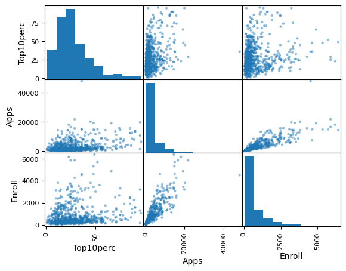

```python
pd.plotting.scatter_matrix(college[['Top10perc', 'Apps', 'Enroll']]);
```

$e)$

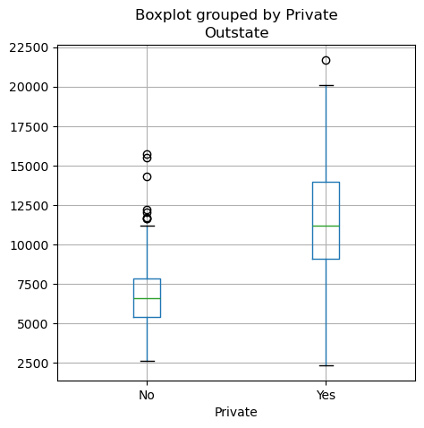

```python
fig, ax = subplots(figsize=(5, 5))
college.boxplot('Outstate', by='Private', ax=ax);
```

$f)$

```python
college['Elite'] = pd.cut(college['Top10perc'], [0,50,100], labels=['No', 'Yes'])
college.value_counts('Elite')
```

```
Elite
No     699
Yes     78
Name: count, dtype: int64
```

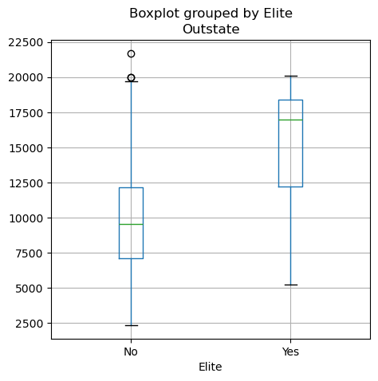

```python
fig, ax = subplots(figsize=(5, 5))
college.boxplot('Outstate', by='Elite', ax=ax);
```

$g)$

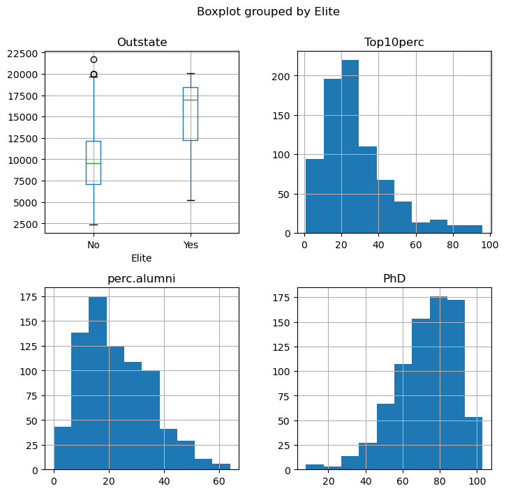

```python
fig, axes = subplots(nrows=2, ncols=2, figsize=(8, 8))
college.boxplot('Outstate', by='Elite', ax=axes[0, 0]);
college.hist('Top10perc', bins=10, ax=axes[0, 1]);
college.hist('perc.alumni', bins=10, ax=axes[1, 0]);
college.hist('PhD', bins=10, ax=axes[1, 1]);
```

$h)$ NA

#### Q9

```python
auto = pd.read_csv('Auto.csv', na_values=['?'])
auto
```

|  | mpg | cylinders | displacement | horsepower | weight | acceleration | year | origin | name |
| --- | --- | --- | --- | --- | --- | --- | --- | --- | --- |
| 0 | 18.0 | 8 | 307.0 | 130.0 | 3504 | 12.0 | 70 | 1 | chevrolet chevelle malibu |
| 1 | 15.0 | 8 | 350.0 | 165.0 | 3693 | 11.5 | 70 | 1 | buick skylark 320 |
| 2 | 18.0 | 8 | 318.0 | 150.0 | 3436 | 11.0 | 70 | 1 | plymouth satellite |
| 3 | 16.0 | 8 | 304.0 | 150.0 | 3433 | 12.0 | 70 | 1 | amc rebel sst |
| 4 | 17.0 | 8 | 302.0 | 140.0 | 3449 | 10.5 | 70 | 1 | ford torino |
| ... | ... | ... | ... | ... | ... | ... | ... | ... | ... |
| 392 | 27.0 | 4 | 140.0 | 86.0 | 2790 | 15.6 | 82 | 1 | ford mustang gl |
| 393 | 44.0 | 4 | 97.0 | 52.0 | 2130 | 24.6 | 82 | 2 | vw pickup |
| 394 | 32.0 | 4 | 135.0 | 84.0 | 2295 | 11.6 | 82 | 1 | dodge rampage |
| 395 | 28.0 | 4 | 120.0 | 79.0 | 2625 | 18.6 | 82 | 1 | ford ranger |
| 396 | 31.0 | 4 | 119.0 | 82.0 | 2720 | 19.4 | 82 | 1 | chevy s-10 |

397 rows × 9 columns

$a)$

- All predictors are quantitative except for `name`. However, the number of unique elements for `origin` is quite limited (ranging from 1 to 3) so it can be considered to be qualitative with corresponding quality 1 - 3
- Similarly, `cylinders` and `year` can also be qualitative.

$b)$

```python
print('Max values:')
print(np.max(auto[['cylinders', 'year', 'origin']], axis=0))
print('Min values:')
print(np.min(auto[['cylinders', 'year', 'origin']], axis=0))
```

```
Max values:
cylinders     8
year         82
origin        3
dtype: int64
Min values:
cylinders     3
year         70
origin        1
dtype: int64
```

$c)$

```python
auto.drop(['cylinders', 'year', 'origin'], axis=1).describe()
```

|  | mpg | displacement | horsepower | weight | acceleration |
| --- | --- | --- | --- | --- | --- |
| count | 397.000000 | 397.000000 | 392.000000 | 397.000000 | 397.000000 |
| mean | 23.515869 | 193.532746 | 104.469388 | 2970.261965 | 15.555668 |
| std | 7.825804 | 104.379583 | 38.491160 | 847.904119 | 2.749995 |
| min | 9.000000 | 68.000000 | 46.000000 | 1613.000000 | 8.000000 |
| 25% | 17.500000 | 104.000000 | 75.000000 | 2223.000000 | 13.800000 |
| 50% | 23.000000 | 146.000000 | 93.500000 | 2800.000000 | 15.500000 |
| 75% | 29.000000 | 262.000000 | 126.000000 | 3609.000000 | 17.100000 |
| max | 46.600000 | 455.000000 | 230.000000 | 5140.000000 | 24.800000 |

$d)$

```python
auto.drop(range(10, 86)).describe()
```

|  | mpg | cylinders | displacement | horsepower | weight | acceleration | year | origin |
| --- | --- | --- | --- | --- | --- | --- | --- | --- |
| count | 321.000000 | 321.000000 | 321.000000 | 317.000000 | 321.000000 | 321.000000 | 321.000000 | 321.000000 |
| mean | 24.444860 | 5.370717 | 187.174455 | 101.003155 | 2933.183801 | 15.709034 | 77.143302 | 1.598131 |
| std | 7.899928 | 1.653486 | 99.864568 | 36.003208 | 809.638650 | 2.706441 | 3.128202 | 0.816163 |
| min | 11.000000 | 3.000000 | 68.000000 | 46.000000 | 1649.000000 | 8.500000 | 70.000000 | 1.000000 |
| 25% | 18.000000 | 4.000000 | 100.000000 | 75.000000 | 2215.000000 | 14.000000 | 75.000000 | 1.000000 |
| 50% | 23.900000 | 4.000000 | 145.000000 | 90.000000 | 2795.000000 | 15.500000 | 77.000000 | 1.000000 |
| 75% | 30.700000 | 6.000000 | 250.000000 | 115.000000 | 3504.000000 | 17.300000 | 80.000000 | 2.000000 |
| max | 46.600000 | 8.000000 | 455.000000 | 230.000000 | 4997.000000 | 24.800000 | 82.000000 | 3.000000 |

$e)$

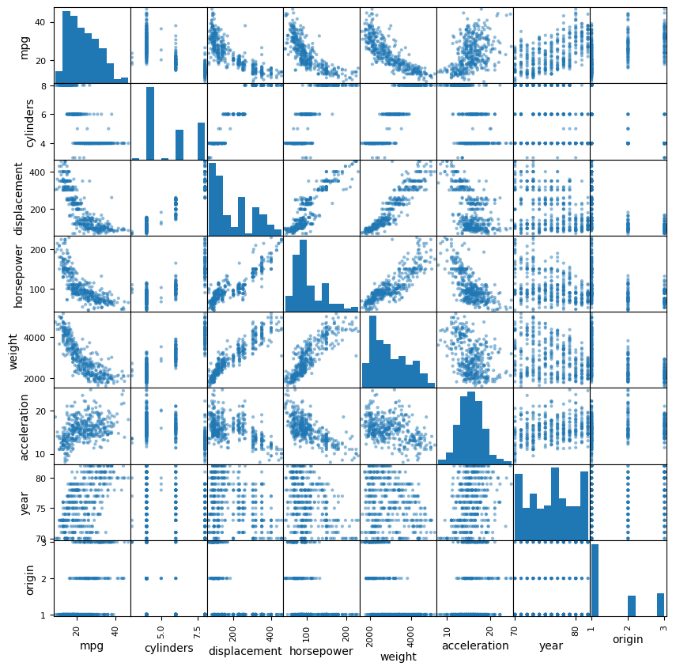

```python
pd.plotting.scatter_matrix(auto, figsize=(10, 10));
```

Comments: NA

$f)$

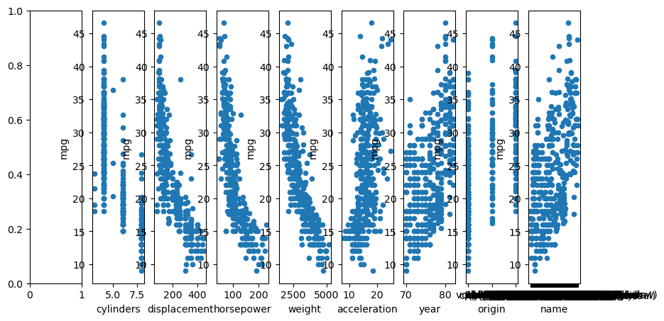

```python
fig, axes = subplots(ncols=len(auto.columns), figsize=(10, 5))
for i, predictor in enumerate(auto.columns):
    if predictor != 'mpg':
        auto.plot.scatter(predictor, 'mpg', ax=axes[i]);
        # print(predictor)
```

#### Q10

$a)$

```python
from ISLP import load_data
Boston = load_data('Boston')
Boston
```

|  | crim | zn | indus | chas | nox | rm | age | dis | rad | tax | ptratio | lstat | medv |
| --- | --- | --- | --- | --- | --- | --- | --- | --- | --- | --- | --- | --- | --- |
| 0 | 0.00632 | 18.0 | 2.31 | 0 | 0.538 | 6.575 | 65.2 | 4.0900 | 1 | 296 | 15.3 | 4.98 | 24.0 |
| 1 | 0.02731 | 0.0 | 7.07 | 0 | 0.469 | 6.421 | 78.9 | 4.9671 | 2 | 242 | 17.8 | 9.14 | 21.6 |
| 2 | 0.02729 | 0.0 | 7.07 | 0 | 0.469 | 7.185 | 61.1 | 4.9671 | 2 | 242 | 17.8 | 4.03 | 34.7 |
| 3 | 0.03237 | 0.0 | 2.18 | 0 | 0.458 | 6.998 | 45.8 | 6.0622 | 3 | 222 | 18.7 | 2.94 | 33.4 |
| 4 | 0.06905 | 0.0 | 2.18 | 0 | 0.458 | 7.147 | 54.2 | 6.0622 | 3 | 222 | 18.7 | 5.33 | 36.2 |
| ... | ... | ... | ... | ... | ... | ... | ... | ... | ... | ... | ... | ... | ... |
| 501 | 0.06263 | 0.0 | 11.93 | 0 | 0.573 | 6.593 | 69.1 | 2.4786 | 1 | 273 | 21.0 | 9.67 | 22.4 |
| 502 | 0.04527 | 0.0 | 11.93 | 0 | 0.573 | 6.120 | 76.7 | 2.2875 | 1 | 273 | 21.0 | 9.08 | 20.6 |
| 503 | 0.06076 | 0.0 | 11.93 | 0 | 0.573 | 6.976 | 91.0 | 2.1675 | 1 | 273 | 21.0 | 5.64 | 23.9 |
| 504 | 0.10959 | 0.0 | 11.93 | 0 | 0.573 | 6.794 | 89.3 | 2.3889 | 1 | 273 | 21.0 | 6.48 | 22.0 |
| 505 | 0.04741 | 0.0 | 11.93 | 0 | 0.573 | 6.030 | 80.8 | 2.5050 | 1 | 273 | 21.0 | 7.88 | 11.9 |

506 rows × 13 columns

$b)$

- 506 rows. Each is an observation
- 13 cols. Each column is a predictor
- refer to https://islp.readthedocs.io/en/latest/datasets/Boston.html for detail on each predictor

$c)$

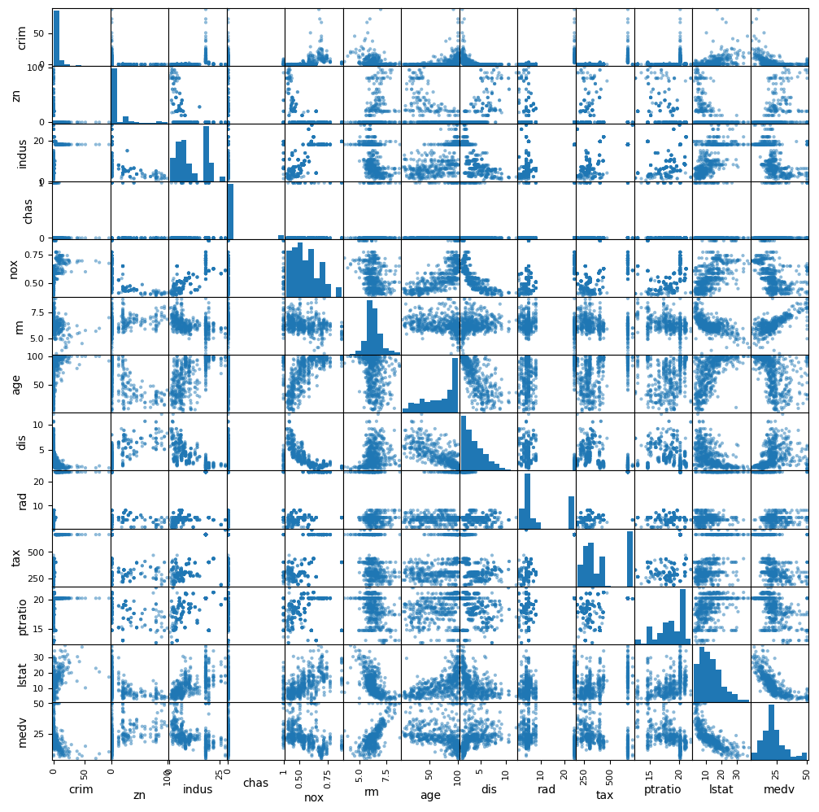

```python
pd.plotting.scatter_matrix(Boston, figsize=(12, 12));
```

$d)$ Refer to scatter matrix of part ($c$), first row for `crim`, there is no graph that shows a clear relationship between other predictors and crime rate. `Istat` (lower status of the population (percent)) and `age` have the clearest positive proportion with crime rate. `medv` (median value of owner-occupied homes in $1000s) has negative relationship with crime rate. However, definitive conclusion needs proper statistical testing

$e)$ NA

$f)$ NA

$g)$

```python
Boston['ptratio'].describe()
```

```
count    506.000000
mean      18.455534
std        2.164946
min       12.600000
25%       17.400000
50%       19.050000
75%       20.200000
max       22.000000
Name: ptratio, dtype: float64
```

$h)$

```python
# Extracting suburb with lowest `medv`
min_medv_index = Boston['medv'].idxmin()
min_medv_suburb = Boston.loc[min_medv_index]
min_medv_suburb
```

```
crim        38.3518
zn           0.0000
indus       18.1000
chas         0.0000
nox          0.6930
rm           5.4530
age        100.0000
dis          1.4896
rad         24.0000
tax        666.0000
ptratio     20.2000
lstat       30.5900
medv         5.0000
Name: 398, dtype: float64
```

```python
Boston.describe().loc[['min', 'max']]._append(min_medv_suburb)
```

|  | crim | zn | indus | chas | nox | rm | age | dis | rad | tax | ptratio | lstat | medv |
| --- | --- | --- | --- | --- | --- | --- | --- | --- | --- | --- | --- | --- | --- |
| min | 0.00632 | 0.0 | 0.46 | 0.0 | 0.385 | 3.561 | 2.9 | 1.1296 | 1.0 | 187.0 | 12.6 | 1.73 | 5.0 |
| max | 88.97620 | 100.0 | 27.74 | 1.0 | 0.871 | 8.780 | 100.0 | 12.1265 | 24.0 | 711.0 | 22.0 | 37.97 | 50.0 |
| 398 | 38.35180 | 0.0 | 18.10 | 0.0 | 0.693 | 5.453 | 100.0 | 1.4896 | 24.0 | 666.0 | 20.2 | 30.59 | 5.0 |

Comments: NA

$i)$

```python
def get_num_sub_from_predictor(predictor, amount):
    idx = Boston[predictor] > amount
    return Boston.loc[idx].shape[0]

print('Number of suburbs average more than 7 rooms per dwelling: ' + str(get_num_sub_from_predictor('rm', 7)))
print('Number of suburbs average more than 8 rooms per dwelling: ' + str(get_num_sub_from_predictor('rm', 8)))
```

```
Number of suburbs average more than 7 rooms per dwelling: 64
Number of suburbs average more than 8 rooms per dwelling: 13
```